# Лабораторная работа №3

Ефременко Влада

2022-11-28

## Задание 6

ExpImp.Rdata Приведите данные к формату tidydata. Отобразите значения суммарного экспорта и импорта по регионам в виде столбчатой диаграммы [сгруппировав значения по названию региона]. Экспорт и импорт обозначьте разными цветами. Сделайте второй график, на котором значения экспорта и импорта расположите по разные стороны относительно оси x. Подпишите величины экспорта и импорта.

Используемые пакеты:

```r
library(stringr)
library(dplyr)
```

```r
library(tidyr)
library(ggplot2)
```

Путь до файла с данными и константа:

```r
path = '/Users/vladaefremenko/R_Lab3/data/ExpImp.RData'
REGION <- 'Сибирский федеральный округ'
```

Функция, отрисовывающая графики:

```r
plot_graphics <- function(data, str){
  data <- data[complete.cases(data),]
  for (i in 2:length(names(data))) {
    data[[i]] <- gsub("-", 0, data[[i]])
    data[[i]] <- as.numeric(data[[i]])
  }

  flt <- str_detect(data$Регион, 'федеральный округ')
  rdf <- mutate(data, Округ = if_else(flt, Регион, NULL))
  rdf <- fill(rdf, Округ)
  flt2 <- !str_detect(rdf$Регион, 'Федерация|федеральный округ')
  rdf <- filter(rdf, flt2)

  match_exp <- select_at(rdf, vars(matches("Экспорт")))
  match_imp <- select_at(rdf, vars(matches("Импорт")))

  match_exp$Сумма <- rowSums(match_exp, na.rm = TRUE)
  match_imp$Сумма <- rowSums(match_imp, na.rm = TRUE)

  rdf$SumExport <- match_exp$Сумма
  rdf$SumImport <- match_imp$Сумма

  if (str == 'Reflect'){
    rdf[,"SumImport"] <- -rdf[,"SumImport"]
  }

  rdf <- filter(rdf, Округ == REGION)
  rdf <- rdf[,c("Регион", "SumExport", "SumImport" )]
  rdf <- pivot_longer(rdf, !Регион, names_to = "Экспорт/Импорт", values_to = "млн долларов США")


  sum_reg <- rdf %>% group_by(Регион, `Экспорт/Импорт`)
  sum_reg <- sum_reg %>% summarise(sum = sum(`млн долларов США`))

  sum_reg |>
    ggplot(mapping = aes(x = Регион, y = sum, fill = `Экспорт/Импорт`)) +
    geom_col(color = 'black', size = 0.2, position = 'dodge') +
    ggtitle(REGION) + ylab('млн долларов США') + coord_flip()
    #geom_text(aes(label = sum), hjust=0.5, vjust = 1, angle = 45)
}
```

Исполняемый код - считываем данные, строим графики с неотраженными и отраженными столбцами диаграммы:

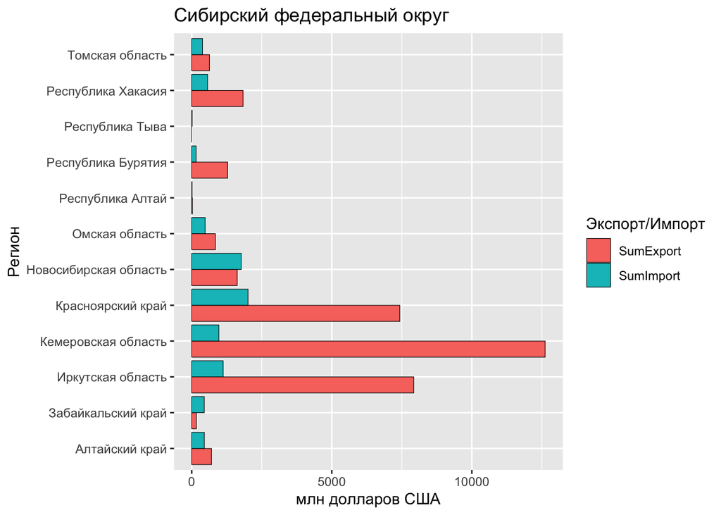

```r
load(path)
plot_graphics(ExpImp, 'Non-reflect')
```

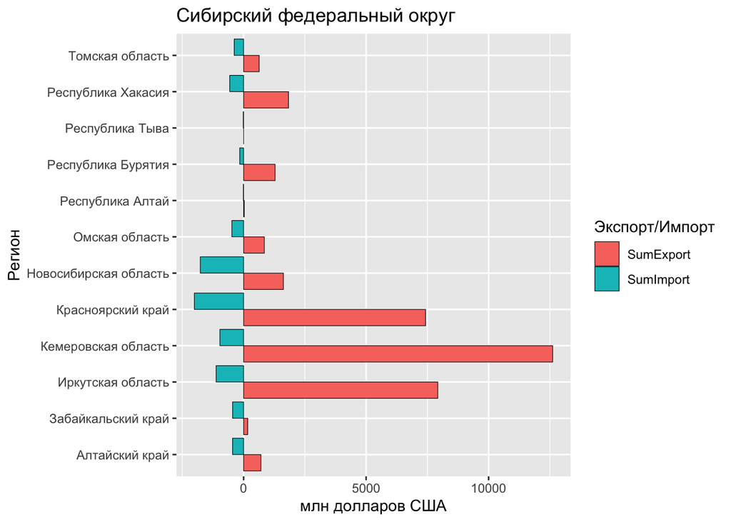

```r
plot_graphics(ExpImp, 'Reflect')
```

***

## Задание 11

На портале открытых данных Тульской области есть данные о распределении площади лесов и запасов древесины по преобладающим породам и группам возраста https://opendata71.ru/opendata/7107096442-stateforestregisterTularegion/table. Скачайте эти данные в виде таблицы CSV и постройте по ним круговую и столбчатую диаграмму для категории Площадь земель, занятых лесными насаждениями (покрытых лесной растительностью), всего. Подберите цвета, попробуйте изменить ориентировку столбцов на горизонтальную, а для круговой диаграммы поменяейте угол поворота. Подпишите значения.

Используемые пакеты:

```r
library(ggplot2)
```

Путь до файла с данными:

```r
path = '/Users/vladaefremenko/R_Lab3/data/data_tula.csv'
```

Функция, отрисовывающая графики:

```r
plot_graphics <- function(df){
  gg1 <- ggplot(data = df, mapping = aes(x = Breeds, y = Value_indicator, fill = Breeds)) +
    geom_col() + coord_flip() +
    xlab("Породы") + ylab("Тыс. га") +
    ggtitle('Площадь земель, занятых лесными насаждениями') +
    geom_text(aes(label = Value_indicator), vjust = 0.5)

  gg1 <- gg1 + guides( fill = guide_legend(title = "Породы", override.aes = aes(label = "")))
  print(gg1)

  gg2 <- ggplot(data = df, mapping = aes(x = '', y = Value_indicator, fill = Breeds)) +
    geom_col() + coord_polar(theta = 'y') +
    ggtitle('Площадь земель, занятых лесными насаждениями') + ylab('Тыс. га')
  gg2 <- gg2 + guides(fill = guide_legend(title = "Породы", override.aes = aes(label = "")))
  print(gg2)
}
```

Исполняемый код - считываем данные из .csv файла, меняем названия столбцов в датафрейме, выбираем нужные столбцы, меняем тип переменной на вещественную и строим графики:

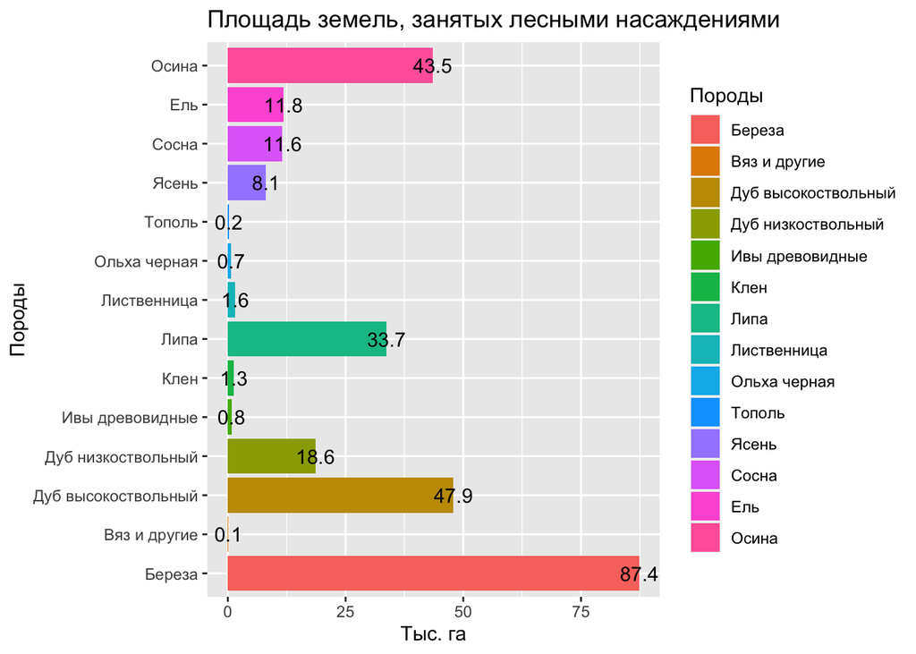

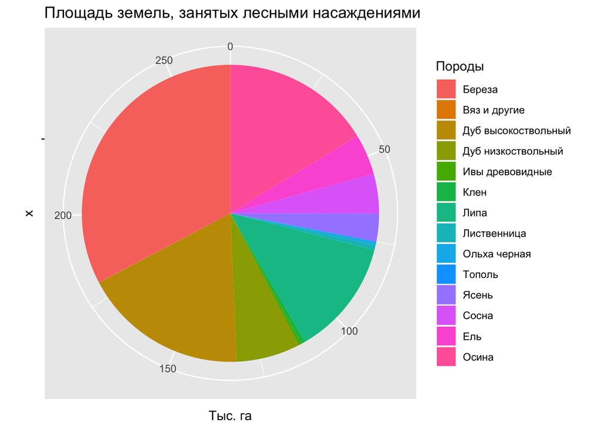

```r
data <- read.csv(path, sep=";")
colnames(data) <- c("Breeds", "Name_indicator", "Unit", "Value_indicator")
new_data <- subset(data, Name_indicator == "Площадь земель, занятых лесными насаждениями (покрытых лесной растительностью), всего")
new_data[[4]] <- sub(',', '.', new_data[[4]])
new_data[[4]] <- as.numeric(new_data[[4]])
plot_graphics(new_data)
```